# Twitter during electoral campaign: most discussed topics by italian parties

Simone Travaglini

2022-12-22

GitHub repository link: https://github.com/DataAccess2020/Capstone_TravagliniSimone

GitHub statistics: number of commit –> 51

## INTRODUCTION:

On 21 July 2022 the president of the Republic **Sergio Mattarella** proclaimed the dissolution of parliament, following the resignation presented by prime minister Mario Draghi. early elections were called for 25 september: in those months, therefore, the parties began their electoral campaign. Said that, this brief analysis aims to see which topics were most discussed by the main political actors and the candidates for the Chamber of Deputies and the Senate. in order to do so, I will use the twitter profiles, both personal and of the political parties of the main coalitions: **right coalition, left coalition, 5 star movement and Azione-Italia Viva**.

## METHODOLOGY:

As mentioned in the introduction, to do this I analysed the twitter profiles of Italian political actors. The first step in this analysis was to search for the various profiles and insert them, via my twitter profile, within 4 different lists, each concerning a coalition. The lists were composed as follows:

1. **Right coalition:** 80 members –> https://twitter.com/i/lists/1602429027561750528
2. **Left coalition:** 66 members –> https://twitter.com/i/lists/1602661051400654850
3. **M5s:** 61 members –> https://twitter.com/i/lists/1602433071604801537
4. **Third pole:** 35 members –> https://twitter.com/i/lists/1602680072506408960

```r
library(rtweet)
library(tidyverse)
library(dplyr)


auth_setup_default()

#cdx list number 1602429027561750528-------
italian_cdx = lists_members(
  list_id = "1602429027561750528",
  owner_user = NULL,
  slug = NULL,
  cursor = "-1",
  token = NULL,
  retryonratelimit = TRUE,
  parse = TRUE,
  verbose = TRUE,

)

#csx list number 1602661051400654850------
italian_csx = lists_members(
  list_id = "1602661051400654850",
  owner_user = NULL,
  slug = NULL,
  cursor = "-1",
  token = NULL,
  retryonratelimit = TRUE,
  parse = TRUE,
  verbose = TRUE,

)

#terzo polo list number 1602680072506408960-------
italian_terzopolo = lists_members(
  list_id = "1602680072506408960",
  owner_user = NULL,
  slug = NULL,
  cursor = "-1",
  token = NULL,
  retryonratelimit = TRUE,
  parse = TRUE,
  verbose = TRUE,

)

#m5s list number 1602433071604801537---------
italian_m5s = lists_members(
  list_id = "1602433071604801537",
  owner_user = NULL,
  slug = NULL,
  cursor = "-1",
  token = NULL,
  retryonratelimit = TRUE,
  parse = TRUE,
  verbose = TRUE,

)
```

## DATA PROCESSING FOR ANALYSIS

After importing the lists from twitter i had to create objects with lists of all the politicians’ names using the *unlist* function. These lists were *data frames* containing a lot of information that i did not need. What i was interested in was the **$screen_name**.

```r
library(rtweet)
library(tidyverse)
library(dplyr)

list_italian_cdx = c(italian_cdx$screen_name)
list_italian_csx = c(italian_csx$screen_name)
list_italian_m5s = c(italian_m5s$screen_name)
list_italian_terzopolo = c(italian_terzopolo$screen_name)
```

This was useful because I needed the ids to download the tweets of each politician. The main problem in this process was setting up a filter, so that i could only get tweets from july to september. The first method was to set up only the filter with dplyr, but that didn’t work. Next, i had to set the since_id and max_id in the function *get_timeline* and *n = Inf.* In order to do that i took 2 tweets by the Matteo Salvini twitter account.

```r
since <- "1551558900247314435"
max <- "1573269167305854976"
cdx_tweet <- rtweet::get_timeline(retryonratelimit = T,
                                      user = list_italian_cdx,
                                      n = Inf,
                                      since_id = since,
                                      max_id = max,
                                      verbose = T,
                                      parse = T,
) %>%
  dplyr::filter(created_at > "2022-07-25" & created_at <="2022-09-24")
```

Thanks to this, I was able to download only the tweets of the period that interested me and I therefore also replied for the other coalitions. The partial output was a dataframe for each coalition containing all the tweets. I then proceeded to export these tables in csv format which I saved in a new folder called **“data”**.

```r
#export data
write.csv(cdx_tweet,"C:\\Users\\trava\\OneDrive\\Documenti\\Capstone_TravagliniSimone\\data\\cdx_tweet.csv", row.names=FALSE)
write.csv(csx_tweet,"C:\\Users\\trava\\OneDrive\\Documenti\\Capstone_TravagliniSimone\\data\\csx_tweet.csv", row.names=FALSE)
write.csv(m5s_tweet,"C:\\Users\\trava\\OneDrive\\Documenti\\Capstone_TravagliniSimone\\data\\m5s_tweet.csv", row.names=FALSE)
write.csv(terzopolo_tweet,"C:\\Users\\trava\\OneDrive\\Documenti\\Capstone_TravagliniSimone\\data\\terzopolo_tweet.csv", row.names=FALSE)
```

## GET THE HASHTAGS

After analyzing the tables containing the tweets I decided that the best way to get hashtags was to use a *regular expression*. The regular expression i found was **“#\S+.”** To achieve the goal I then proceeded to create 4 objects containing the lists of all tweets through the unlist function. After that i used the *str_view_all* and *str_extract_all* functions to see and export all the hashtags. finally I put them into objects called **hashtag_cdx, hashtag_csx, hashtag_m5s** and **hashtag_terzopolo**.

```r
list_cdx_tweet <- unlist(cdx_tweet$full_text)
list_cdx_tweet

list_csx_tweet <- unlist(csx_tweet$full_text)
list_csx_tweet

list_m5s_tweet <- unlist(m5s_tweet$full_text)
list_m5s_tweet

list_terzopolo_tweet <- unlist(terzopolo_tweet$full_text)
list_terzopolo_tweet

# open package
library(stringr)

#view if the regex is right
str_view_all(list_cdx_tweet,
             pattern = "#\\S+.")

#probably "#\\S+." is the right one
## cdx----
hashtag_cdx <- str_extract_all(list_cdx_tweet, pattern = "#\\S+.")
## csx----
hashtag_csx <- str_extract_all(list_csx_tweet, pattern = "#\\S+.")
## m5s----
hashtag_m5s <- str_extract_all(list_m5s_tweet, pattern = "#\\S+.")
## terzopolo----
hashtag_terzopolo <- str_extract_all(list_terzopolo_tweet, pattern = "#\\S+.")
```

```r
library(wordcloud)

library(RColorBrewer)

library(wordcloud2)

## cdx----

#create a corpus

library(tm)


tweet_dx <- unlist(hashtag_cdx)
tweet_dx1 <- Corpus(VectorSource(tweet_dx))

#remove the symbol # and punctation
tweet_dx1 <- tweet_dx1 %>%
  tm_map(removeNumbers) %>%
  tm_map(removePunctuation) %>%
  tm_map(stripWhitespace)
tweet_dx1 <- tm_map(tweet_dx1, content_transformer(tolower))
tweet_dx1 <- tm_map(tweet_dx1, removeWords, stopwords("english"))

dtm <- TermDocumentMatrix(tweet_dx1)
matrix <- as.matrix(dtm)
words <- sort(rowSums(matrix),decreasing=TRUE)
df <- data.frame(word = names(words),freq=words)


## csx----

tweet_sx <- unlist(hashtag_csx)
tweet_sx1 <- Corpus(VectorSource(tweet_sx))

#remove the symbol # and punctation
tweet_sx1 <- tweet_sx1 %>%
  tm_map(removeNumbers) %>%
  tm_map(removePunctuation) %>%
  tm_map(stripWhitespace)
tweet_sx1 <- tm_map(tweet_sx1, content_transformer(tolower))
tweet_sx1 <- tm_map(tweet_sx1, removeWords, stopwords("english"))

dtm2 <- TermDocumentMatrix(tweet_sx1)
matrix2 <- as.matrix(dtm2)
words2 <- sort(rowSums(matrix2),decreasing=TRUE)
df2 <- data.frame(word = names(words2),freq=words2)

## m5s----
tweet_m5s <- unlist(hashtag_m5s)
tweet_m5s1 <- Corpus(VectorSource(tweet_m5s))

#remove the symbol # and punctation
tweet_m5s1 <- tweet_m5s1 %>%
  tm_map(removeNumbers) %>%
  tm_map(removePunctuation) %>%
  tm_map(stripWhitespace)
tweet_m5s1 <- tm_map(tweet_m5s1, content_transformer(tolower))
tweet_m5s1 <- tm_map(tweet_m5s1, removeWords, stopwords("english"))

dtm3 <- TermDocumentMatrix(tweet_m5s1)
matrix3 <- as.matrix(dtm3)
words3 <- sort(rowSums(matrix3),decreasing=TRUE)
df3 <- data.frame(word = names(words3),freq=words3)

### terzopolo-----
tweet_tp <- unlist(hashtag_terzopolo)
tweet_tp1 <- Corpus(VectorSource(tweet_tp))

#remove the symbol # and punctation
tweet_tp1 <- tweet_tp1 %>%
  tm_map(removeNumbers) %>%
  tm_map(removePunctuation) %>%
  tm_map(stripWhitespace)
tweet_tp1 <- tm_map(tweet_tp1, content_transformer(tolower))
tweet_tp1 <- tm_map(tweet_tp1, removeWords, stopwords("english"))

dtm4 <- TermDocumentMatrix(tweet_tp1)
matrix4 <- as.matrix(dtm4)
words4 <- sort(rowSums(matrix),decreasing=TRUE)
df4 <- data.frame(word = names(words4),freq=words4)
```

## OUTPUT ANALYSIS:

*LEFT COALITION:*

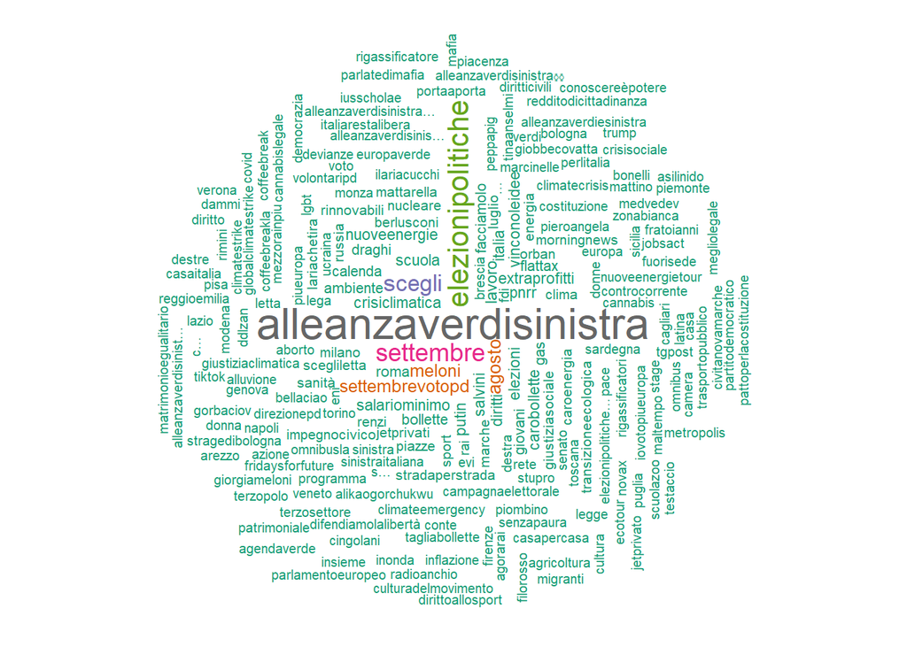

As we can see from the graphs above, the most used hashtags are green-left alliance and in any case those related to the environment and ecology (*climate crisis, regasification terminals* and *ecological transition* above all). however, there are also references to political opponents (especially **Meloni, Salvini** and **Calenda**). Another fundamental point of the electoral campaign for the left was the right for homosexuals and the lgbt community. As seen in the wordcloud among the hashtags there are **“egalitarian marriage” “lgbt”** and **“rights”**. In the graph below instead we can see the 30 most used hashtags by the coalition: The first one was *“alleanzaverdisinistra”*, used more then 1000 times. It would also be interesting to understand why this hashtag was used so many times. Most likely, the party candidates were the most active in the campaign, compared to the other coalition members. As for the other hashtags, the most mentioned political enemy was Meloni, a member of Fratelli d’Italia and a member of the right-wing coalition. Among the 30 most used hashtags also appear labour, climate crisis, extra profits and high utility bills, topics that have always been close to the Italian left.

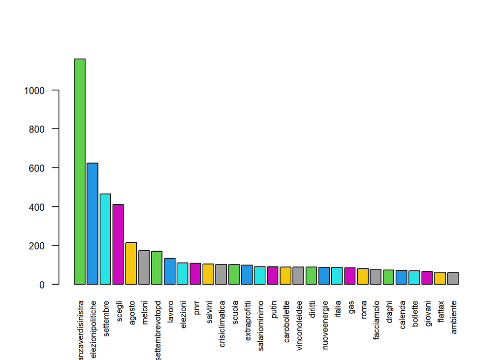

*RIGHT COALITION:*

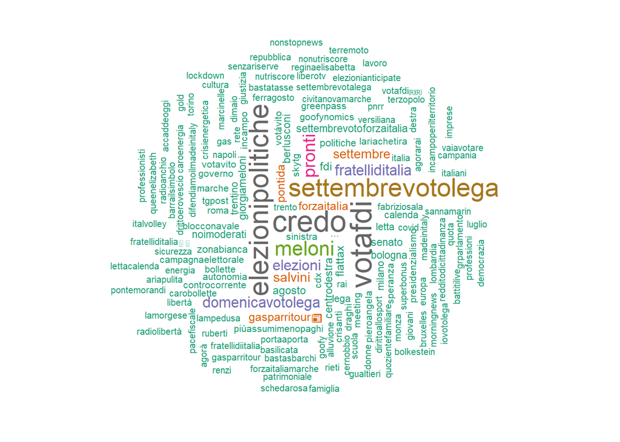

The graphs show that the words most used by right-wing coalition politicians are those referring to voting for a reference party (lega, fdi and forza italia), but there are also hashtags referring to the main points of their electoral campaign (presidentialism, flat tax). One of the main ones is the hashtag #credo, launched on the occasion of the elections by the leader of the Lega Matteo Salvini. In the graph below instead we can see the 30 most used hashtags by the coalition: the first was #credo, that was mentioned more than 500 times. With regard to the other hashtags, the most used were those referring to the parties in the coalition (*Lega, Fratelli d’Italia, Forza Italia, Noi Noderati*) or to the leaders of the parties (**Meloni, Berlusconi, Salvini**). In general, there were few references to the issues close to the italian right, but they were much more personalised. Another hashtag that was used a lot was *‘Pontida’*, the place of the historic meeting of lega supporters. With regard to political opponents, the most mentioned was *Enrico Letta*.

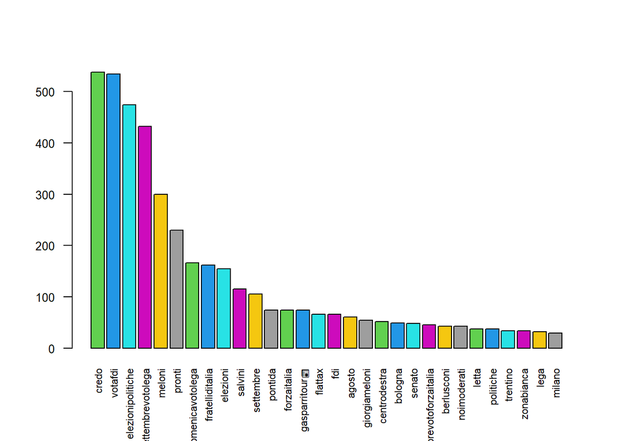

*MOVIMENTO 5 STELLE ANALYSIS:*

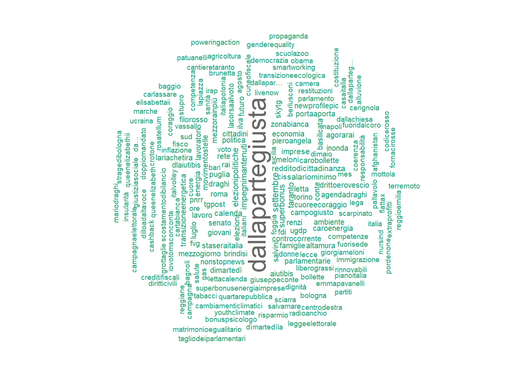

As regards the analysis of the Movimento 5 stelle, I must say that I found a principal difficulty: the candidates of the movement (except for a few cases) did not use twitter much during the electoral campaign. Although the list was large enough, I was able to export only **2760** tweets. However we can say that, from the analysis of these hashtags, the one most used by far was **“dalla parte giusta”**. Secondly, the others were those referring to *basic income* and *the minimum wage*, but also *young people* and *expensive bills*. Also in this case we find references to political opponents, first of all *Meloni* and *Calenda*, but also *Renzi* and *Letta*. As we can see from the plots here below, the hashtag **“#dallapartegiusta”** was vastly more used than the others, more than 6 times more than the second one. These were the themes most frequently used during the election campaign. I would say that, in many aspects, the Movimento 5 stelle was very close to the themes of the left: it talked about young people, high bills costs (especially for the poorer segments of the population), citizenship income (introduced by the party itself during the last legislature) and the minimum wage.

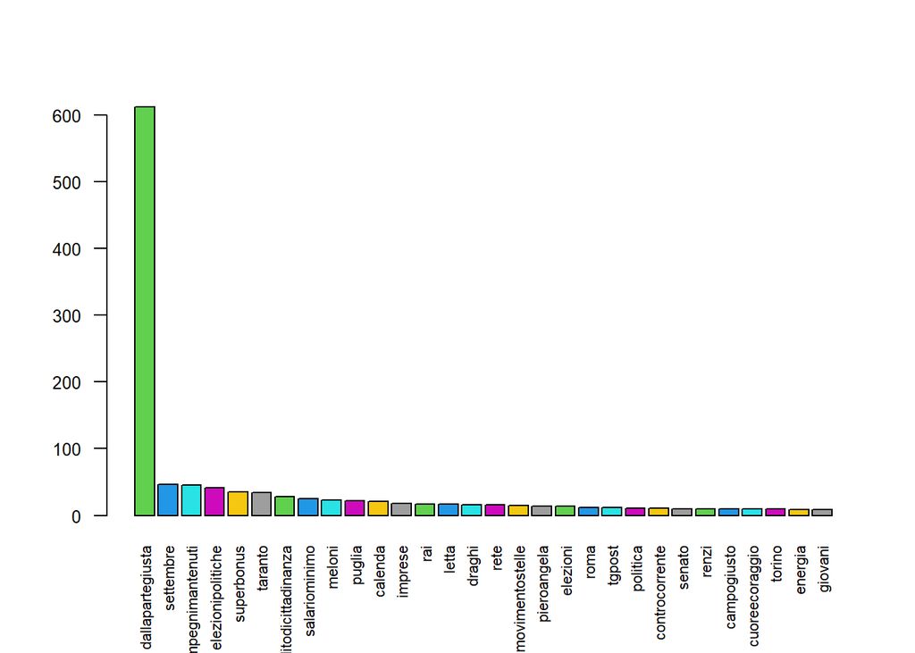

*TERZO POLO ANALYSIS:*

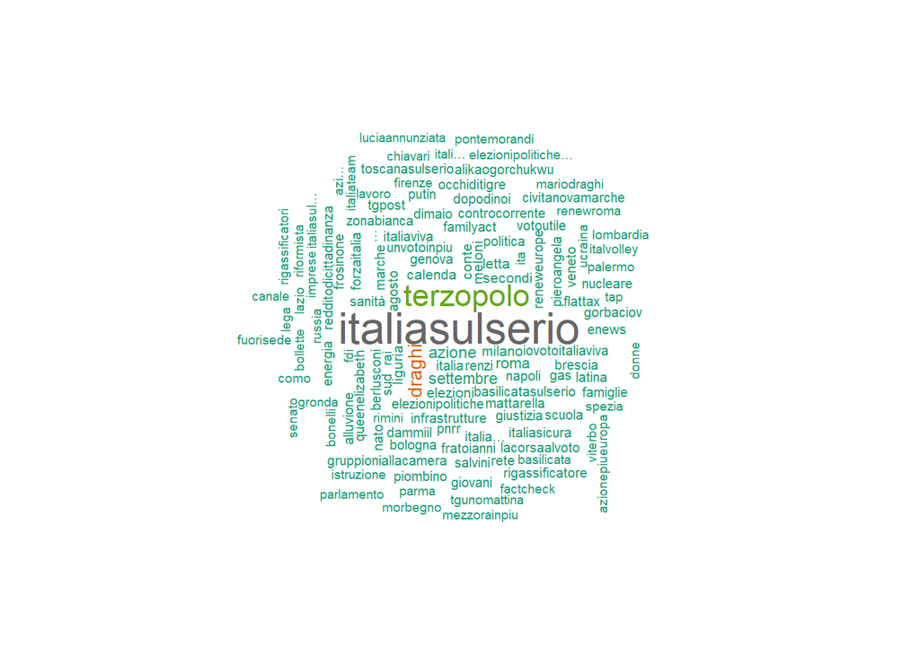

In the graph below instead we can see the 30 most used hashtags by the coalition: the first was **#italiasulserio**, that was mentioned more than 1200 times. Another interesting thing is to find *#Draghi* as the third most used hashtag. Probably in reference to the fact that they were satisfied with Draghi’s performance as head of government and wanted to continue their political action in that direction.

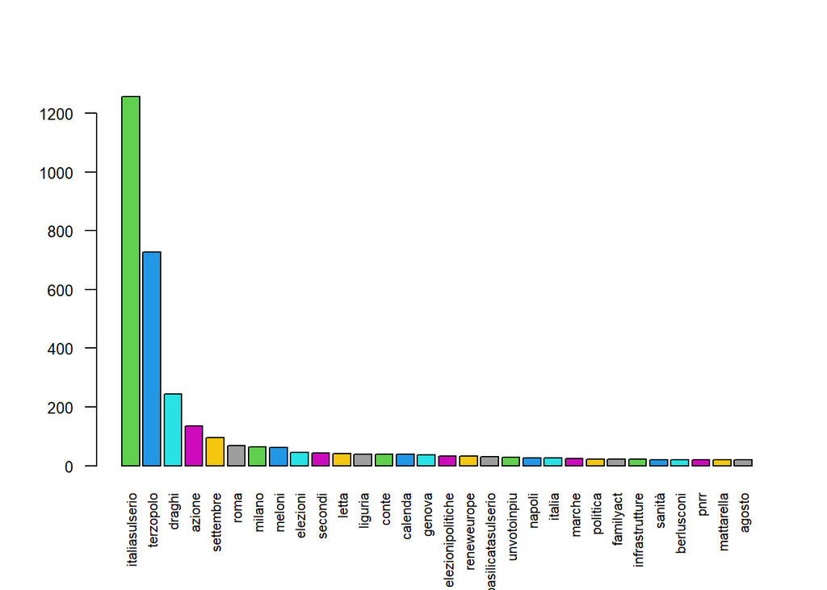

## CONCLUSION

In conclusion, we can say that, all the coalitions have used the twitter channels to talk about their key points on the political agenda, or to refer to and attack their political opponents. from this analysis that only took into consideration the hashtags, I could only understand the topic in question, but not the message that was wanted to be sent. During this electoral campaign, it has been seen that the parties have had a good deal of activity within their twitter accounts, despite the proximity between the day on which president Mattarella proclaimed the dissolution of the chambers and the elections. The actual period was therefore only 2 months.

One consideration that i feel I must make, however, is that in a historical period such as the one in which we live, it is possible to say that the classic electoral campaign no longer exists. I mean that anyone with a twitter profile or any other social media profile can see that most of the Italian political class appears in a perennial political campaign, with the aim of acquiring new voters and maintaining virtual relations with those already acquired. That said, it is probable that even extending the search outside of this time period, we would have found the same topics among the tweets of the analysed politicians.